# Projeto final da disciplina FLS6397

Introdução à Análise de Dados, Programação e Visualização para as Ciências Sociais

Beatriz Milz - Nº 7974879

Julho/2020

HTML compilado em: 22 de julho de 2020

## Introdução

Este arquivo corresponde ao projeto final da disciplina [“FLS6397 - Introdução à Análise de Dados, Programação e Visualização para as Ciências Sociais”](https://jonnyphillips.github.io/Ciencia_de_Dados/). As instruções para a realização do projeto estão disponíveis na [página da disciplina](https://jonnyphillips.github.io/Ciencia_de_Dados/projeto.html).

Esse projeto final foi realizado com R (R Core Team 2019) e o pacote `{rmarkdown}` (Xie, Allaire, and Grolemund 2018; Allaire et al. 2020).

**Objetivos:** Explorar os dados de coleta e tratamento de esgoto para os municípios das seguintes Unidades de Gerenciamento de Recursos Hídricos (**UGRHI**): Paraíba do Sul, Litoral Norte, Piracicaba/Capivari/Jundiaí, Alto Tietê, Baixada Santista e Tietê/Sorocaba. Essas UGRHIs foram escolhidas por estarem totalmente ou marjoritariamente no território da Macrometrópole Paulista (**MMP**) (considerando a delimitação do DAEE[^1]).

## Dados utilizados

- **Dados de Saneamento:** A Companhia Ambiental do Estado de São Paulo (CETESB)[^2] publica todos os anos o “[Relatório de Qualidade das Águas Interiores do Estado de São Paulo](https://cetesb.sp.gov.br/aguas-interiores/publicacoes-e-relatorios/)”. Desde o relatório referente ao ano de 2016, é publicado o **Apêndice C**, que contém **dados de saneamento por município** do Estado de São Paulo. Os arquivos são disponibilizados em arquivo PDF, [e especificamente para o ano de 2016 é um arquivo PDF que não possibilita copiar as informações](https://cetesb.sp.gov.br/aguas-interiores/wp-content/uploads/sites/12/2018/03/Ap%C3%AAndice-C-Dados-do-saneamento-b%C3%A1sico...-munic%C3%ADpios-paulistas-2016_17-04.pdf) (como uma imagem, por exemplo).
- **Dados shapefile dos municípios:** Foi utilizado o pacote `{geobr}` (Pereira and Goncalves 2020), que possibilita acessar dados espaciais oficiais do Brasil.

## Pacotes necessários

```r
library(ggplot2)
library(dplyr)
library(magrittr)
library(geobr)
# install.packages("pdftables")
library(pdftables)
library(readr)
library(stringr)
library(abjutils)
library(ggspatial)
library(tibble)
library(knitr)
library(sf)
```

Referências dos pacotes utilizados: `{abjutils}` (ABJ 2019), `{dplyr}` (Wickham, François, et al. 2020), `{geobr}` (Pereira and Goncalves 2020), `{ggplot2}` (Wickham, Chang, et al. 2020; Wickham 2016), `{ggspatial}` (Dunnington 2020), `{knitr}` (Xie 2020, 2015), `{magrittr}` (Bache and Wickham 2014), `{pdftables}` (Persson 2016), `{readr}` (Wickham, Hester, and Francois 2018), `{rmarkdown}` (Allaire et al. 2020; Xie, Allaire, and Grolemund 2018), `{sf}` (Pebesma 2020, 2018), `{stringr}` (Wickham 2019), `{tibble}` (Müller and Wickham 2020).

## Abrir e arrumar as bases brutas

### Dados de Saneamento

- O primeiro passo é fazer o download do arquivo PDF referente ao Apêndice C e converter em CSV. Para isso, utilizei o pacote `{pdftables}` (Persson 2016), que possibilita converter o PDF para CSV diretamente do R, através da API (e omiti a minha chave da API no código):

```r
url <-
  "https://cetesb.sp.gov.br/aguas-interiores/wp-content/uploads/sites/12/2019/10/Ap%C3%AAndice-C_Dados-de-Saneamento-por-Munic%C3%ADpio.pdf" # link do apêndice C para o ano de 2018

# Comentei os passos de download e conversão do arquivo PDF, pois após a primeira vez, não é preciso repetir essa operação para compilar o arquivo, e deixa o código mais lento.

# Fazer o download do arquivo PDF
# download.file(url,
#               destfile = "dados/apendice_c_2018.pdf",
#               method = "curl")

# Converter o arquivo PDF em CSV. Utilizei a API que obtive no site, mas para compilar, omiti a API key.
# pdftables::convert_pdf("dados/apendice_c_2018.pdf",
#                        output_file = "dados/apendice_c_2018.csv",
#                        api_key = "...")
```

- A tabela convertida em `.csv` pode ser acessada [neste link](https://beatrizmilz.github.io/2020-FLS6397/projeto_final/dados/apendice_c_2018.csv). O próximo passo é abrir a base:

```r
apendice_c_2018 <-
  readr::read_csv(
    "dados/apendice_c_2018.csv",
    col_names = c(
      # define o nome das colunas, pois ao converter para pdf fica desconfigurado (em 2 linhas)
      "ugrhi",
      "municipio",
      "consessao",
      "pop_urbana",
      "atendimento_coleta_porc",
      "atendimento_tratamento_porc",
      "eficiencia",
      "carga_poluidora_potencial",
      "carga_poluidora_remancescente",
      "ictem",
      "corpo_receptor"
    ),
    locale = readr::locale(encoding = "ISO-8859-1"),
    # encoding dos dados
    skip = 5 # Quantas linhas para pular no CSV antes de começar a ler os dados.
  )
```

- A base deve conter 645 linhas, referente ao número de municípios no estado de São Paulo[^3]:

```r
nrow(apendice_c_2018) # consulta quantas linhas tem na base
```

```
## [1] 701
```

- A base contém mais linhas do que municípios. O código abaixo retira linhas que só contém NA, e linhas que não tem dados dos municípios:

```r
apendice_c_filtrado <- apendice_c_2018 %>%
  dplyr::filter_all(dplyr::any_vars(!is.na(.))) %>%  # Retira as linhas que apenas contém NA
  dplyr::filter(!municipio %in% c("Estado de São Paulo", "Município", NA, "MUNICÍPIO")) # Filtrar linhas que não contém municípios
```

- Agora a base tem 645 linhas, o que corresponde aos 645 municípios do estado de SP. É importante também verificar o tipo de dados nas colunas:

```r
tibble::glimpse(apendice_c_filtrado)
```

```
## Rows: 645
## Columns: 11
## $ ugrhi                         <chr> "1", "1", "1", "2", "2", "2", "2", "2...
## $ municipio                     <chr> "Campos do Jordão", "Santo Antônio do...
## $ consessao                     <chr> "SABESP", "SABESP", "SABESP", "SAAE",...
## $ pop_urbana                    <chr> "51440", "4033", "5224", "35604", "18...
## $ atendimento_coleta_porc       <chr> "52", "47", "92", "70", "91", "100", ...
## $ atendimento_tratamento_porc   <chr> "100", "100", "75", "28", "100", "0",...
## $ eficiencia                    <chr> "97", "80", "76", "70", "82", NA, "62...
## $ carga_poluidora_potencial     <chr> "2.778", "218", "282", "1.923", "101"...
## $ carga_poluidora_remancescente <chr> "1.377", "136", "133", "1.659", "26",...
## $ ictem                         <chr> "6,06", "4,65", "6,14", "2,56", "8,22...
## $ corpo_receptor                <chr> "Rio Capivari, Rio Sapucaí-Guaçu e af...
```

- Algumas colunas são de dados numéricos mas que foram carregadas como texto, portanto devem ser convertidas:

```r
apendice_c <- apendice_c_filtrado %>%
  dplyr::mutate(
    pop_urbana = as.double(pop_urbana) ,
    atendimento_coleta_porc = as.double(atendimento_coleta_porc),
    atendimento_tratamento_porc = as.double(atendimento_tratamento_porc),
    eficiencia = as.double(eficiencia),

    # As conversões abaixo tem uma etapa a mais, devido à padronização diferente utilizada com o ponto e a vírgula para representar as casas decimais:
    carga_poluidora_potencial =  stringr::str_replace_all(carga_poluidora_potencial, "\\.", "") %>% as.double(),

    carga_poluidora_remancescente =  stringr::str_replace_all(carga_poluidora_remancescente, "\\.", "") %>% as.double(),
    ictem =  stringr::str_replace_all(ictem, ",", "\\.") %>% as.double()

  )
```

- Agora podemos observar novamente o tipo de dados nas colunas, e verificar se todos os dados estão no formato ideal para a análise:

```r
tibble::glimpse(apendice_c)
```

```
## Rows: 645
## Columns: 11
## $ ugrhi                         <chr> "1", "1", "1", "2", "2", "2", "2", "2...
## $ municipio                     <chr> "Campos do Jordão", "Santo Antônio do...
## $ consessao                     <chr> "SABESP", "SABESP", "SABESP", "SAAE",...
## $ pop_urbana                    <dbl> 51440, 4033, 5224, 35604, 1863, 2598,...
## $ atendimento_coleta_porc       <dbl> 52, 47, 92, 70, 91, 100, 89, 100, 100...
## $ atendimento_tratamento_porc   <dbl> 100, 100, 75, 28, 100, 0, 100, 99, 10...
## $ eficiencia                    <dbl> 97, 80, 76, 70, 82, NA, 62, 75, 86, 8...
## $ carga_poluidora_potencial     <dbl> 2778, 218, 282, 1923, 101, 140, 470, ...
## $ carga_poluidora_remancescente <dbl> 1377, 136, 133, 1659, 26, 140, 210, 1...
## $ ictem                         <dbl> 6.06, 4.65, 6.14, 2.56, 8.22, 1.50, 6...
## $ corpo_receptor                <chr> "Rio Capivari, Rio Sapucaí-Guaçu e af...
```

- Agora a base está pronta para uso!

### Dados shapefile dos município

Os dados foram obtidos com o pacote `geobr`:

```r
municipios_sp <- geobr::read_municipality("SP", 2018)
```

### Lista de UGRHIS

- Eu criei manualmente uma tibble com o número e nome das UGRHIs que farão parte da análise:

```r
ugrhis <- tibble::tibble(
  ugrhi = c("2",
            "3",
            "5",
            "6",
            "7",
            "10"),
  nome_ugrhi = c(
    " Paraíba do Sul",
    " Litoral Norte",
    " Piracicaba/Capivari/Jundiaí",
    " Alto Tietê",
    " Baixada Santista",
    " Tietê/Sorocaba"
  )
)
```

## Unir as bases !

- A base da CETESB não possui o código de município do IBGE (o ideal para fazer o Join). Neste caso, podemos usar o nome do município, porém é preciso padronizar os nomes em relação à maiúsculas/minúsculas, acentos, presença de traços, entre outros. A maior diferença encontrada foi na grafia do nome do município “São Luiz do Paraitinga”: segundo o site da Assembléia Legislativa do Estado de São Paulo, e o site do município, Luiz é escrito com Z, porém a base da CETESB utiliza a forma incorreta: “São Luís do Paraitinga”. Essas inconsistências foram corrigidas com código abaixo:

```r
municipios_sp_limpo <-
  municipios_sp %>% dplyr::mutate(
    nome_muni = stringr::str_to_lower(name_muni),
    nome_muni = stringr::str_replace_all(nome_muni, "-", " "),
    nome_muni = abjutils::rm_accent(nome_muni)
  )

apendice_c_limpo <- apendice_c %>% dplyr::mutate(
  nome_muni =  dplyr::case_when(
    municipio == "São Luís do Paraitinga" ~
      "São Luiz do Paraitinga",
    TRUE ~ municipio
  ),
  nome_muni = stringr::str_to_lower(nome_muni),
  nome_muni = stringr::str_replace_all(nome_muni, "-", " "),
  nome_muni = abjutils::rm_accent(nome_muni))
```

- Após arrumar a base, podemos unir com o Join:

```r
apendice_c_geo <-
  dplyr::full_join(municipios_sp_limpo, apendice_c_limpo) %>%
  dplyr::left_join(ugrhis)

apendice_c_geo %>% nrow() # Confirmando se a nova base tem o número de municípios do estado.
```

```
## [1] 645
```

- Ao unir as bases, temos colunas duplicadas ou desnecessárias, então é interessante removê-las. Após este procedimento, a base será filtrada para que apenas municípios que fazem parte das UGRHIs analisadas estejam na tibble gerada.

Além disso, o valor de porcentagem de atendimento de tratamento de esgoto é um valor de porcentagem em relação ao volume de esgoto **coletado**. Por exemplo, o município de Bertioga, segundo os dados da CETESB para 2018, apresenta uma porcentagem de coleta de apenas 34 % do esgoto gerado, e uma porcentagem de 100 % do esgoto tratado. Isso significa que 100 % do esgoto coletado é tratado, e não mostra a porcentagem de todo esgoto gerado que foi tratado. Para isso, criei também uma coluna (chamada `porc_real_trat`) onde é feito esse cálculo (utilizando a função mutate).

```r
saneamento <- apendice_c_geo %>%
  dplyr::select(-nome_muni,-municipio,-code_state) %>%
  dplyr::filter(ugrhi %in% ugrhis$ugrhi) %>%
  dplyr::mutate(porc_real_trat = atendimento_tratamento_porc * atendimento_coleta_porc / 100) # calcula o número real de porcentagem de tratamento de esgoto.
```

A base final que usaremos na análise contém dados de 171 municípios, que fazem parte de 6UGRHIs diferentes. A soma da população urbana destes municípios é de 32.79 milhões de habitantes, o que corresponde à 75.1 % da população urbana do Estado de São Paulo (segundo os dados da base completa utilizada nessa análise).

## Explorando os dados

Agora temos uma base “limpa”, e podemos explorá-la.

- Dentre os municípios que fazem parte da análise, quais são os municípios com menor porcentagem de atendimento de coleta de esgoto? E de que UGRHI fazem parte?

```r
saneamento %>%
  arrange(atendimento_coleta_porc) %>%
  st_drop_geometry() %>%
  slice(1:10) %>%
  select(name_muni,
         nome_ugrhi,
         consessao,
         atendimento_coleta_porc,
         porc_real_trat) %>%
  DT::datatable(
    colnames = c(
      "Município",
      "UGRHI",
      "Consessão",
      "Atendimento de coleta de esgoto (%)",
      "Tratamento do total de esgoto gerado (%)"
    ),
    caption = "Tabela: 10 municípios com menor porcentagem de atendimento de coleta de esgoto, no ano de 2018, segundo a CETESB (2019)."
  )
```

|  | Município | UGRHI | Consessão | Atendimento de coleta de esgoto (%) | Tratamento do total de esgoto gerado (%) |
| --- | --- | --- | --- | --- | --- |
| 1 | Nazaré Paulista | Piracicaba/Capivari/Jundiaí | SABESP | 14 | 14 |
| 2 | Jarinu | Piracicaba/Capivari/Jundiaí | SABESP | 19 | 19 |
| 3 | Mairiporã | Alto Tietê | SABESP | 25 | 17.75 |
| 4 | Itapecerica Da Serra | Alto Tietê | SABESP | 29 | 28.42 |
| 5 | Igaratá | Paraíba do Sul | SABESP | 31 | 31 |
| 6 | Vargem Grande Paulista | Tietê/Sorocaba | SABESP | 32 | 8.96 |
| 7 | Bertioga | Baixada Santista | SABESP | 34 | 34 |
| 8 | Ilhabela | Litoral Norte | SABESP | 35 | 1.4 |
| 9 | Embu-Guaçu | Alto Tietê | SABESP | 37 | 37 |
| 10 | Santana De Parnaíba | Alto Tietê | SABESP | 38 | 8.36 |

Dentre os municípios avaliados, os 10 municípios com menor percentual de coleta de esgoto tem esse serviço concessionado pela SABESP (Companhia de Saneamento Básico do Estado de São Paulo).

## Visualizando os dados

O código abaixo é referente ao estilo do mapa, que aplicarei em todos os mapas seguintes.

```r
tema_mapa <- theme_bw() +
  theme(
    axis.text.y = element_text(
      angle = 90,
      hjust = 0.5,
      size = 8
    ),
    axis.text.x = element_text(size = 8),
    axis.title.y = element_text(size = rel(0.8)),
    axis.title.x = element_text(size = rel(0.8))
  ) +
  theme(
    panel.grid.major = element_line(
      color = gray(0.9),
      linetype = "dashed",
      size = 0.1
    ),
    panel.background = element_rect(fill = "white") +
      annotation_scale(location = "br", width_hint = 0.30)
  )
```

O mapa abaixo apresenta os municípios que fazem parte da análise, segundo a UGRHI, e a localização destes municípios no Estado de São Paulo:

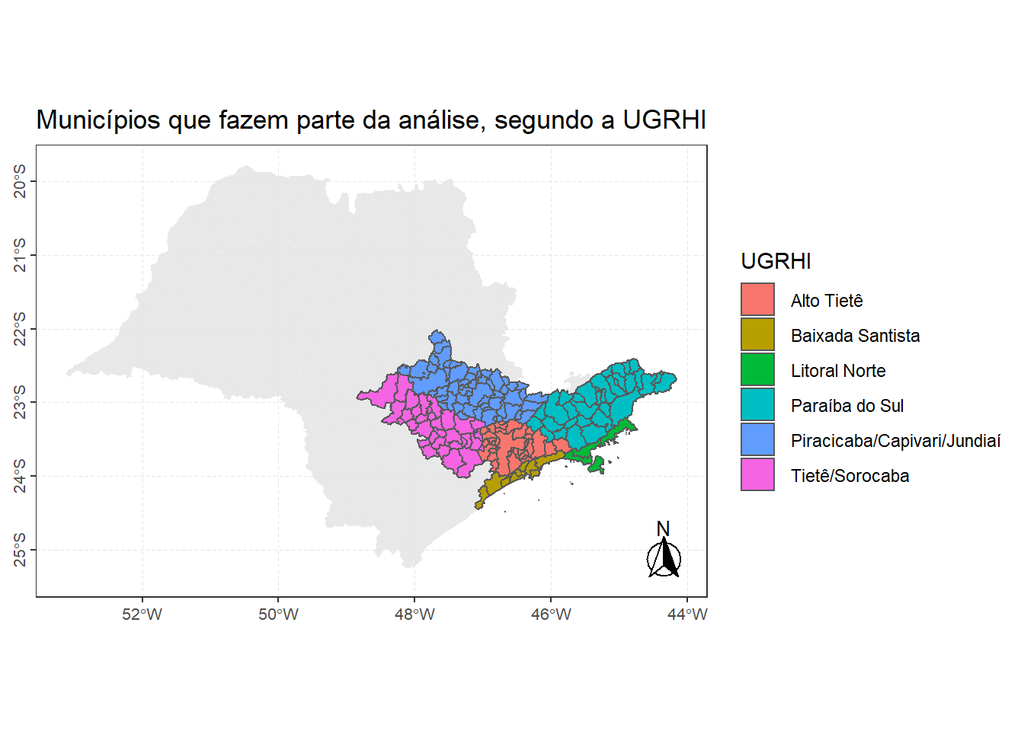

```r
saneamento %>%
  ggplot() +
  geom_sf(data = apendice_c_geo,
          alpha = .9,
          color = NA) +
  geom_sf(aes(fill = nome_ugrhi)) +
  labs(fill = "UGRHI",
       title = "Municípios que fazem parte da análise, segundo a UGRHI") +
  annotation_north_arrow(
    location = "br",
    which_north = "true",
    height = unit(1, "cm"),
    width = unit(1, "cm"),
    pad_x = unit(0.1, "in"),
    pad_y = unit(0.1, "in"),
    style = north_arrow_fancy_orienteering
  ) +
  tema_mapa
```

O mapa abaixo apresenta a porcentagem de atendimento de coleta de esgoto, por município:

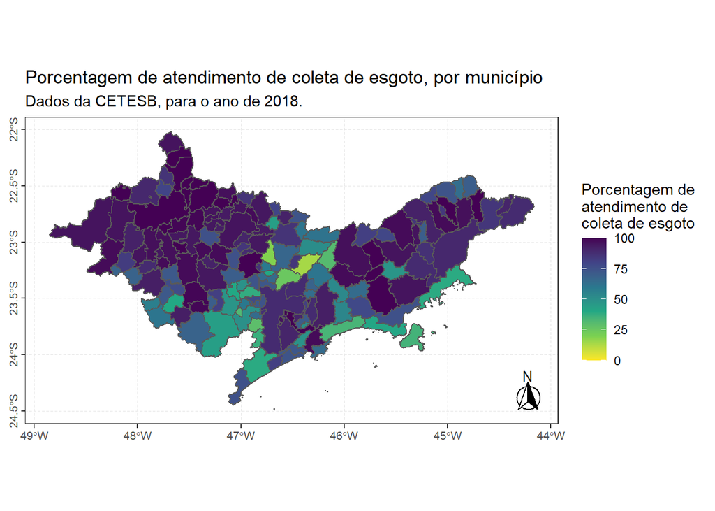

```r
saneamento %>%
  ggplot() +
  geom_sf(aes(fill = atendimento_coleta_porc)) +
  scale_fill_viridis_c(direction = -1, limits = c(0, 100)) +
  theme_bw() +
  labs(fill = "Porcentagem de \natendimento de \ncoleta de esgoto",
       title = "Porcentagem de atendimento de coleta de esgoto, por município",
       subtitle = "Dados da CETESB, para o ano de 2018.") +
  tema_mapa +
  annotation_north_arrow(
    location = "br",
    which_north = "true",
    height = unit(1, "cm"),
    width = unit(1, "cm"),
    pad_x = unit(0.1, "in"),
    pad_y = unit(0.1, "in"),
    style = north_arrow_fancy_orienteering
  )
```

O mapa abaixo apresenta a porcentagem de atendimento de tratamento de esgoto, considerando o total de esgoto coletado, por município:

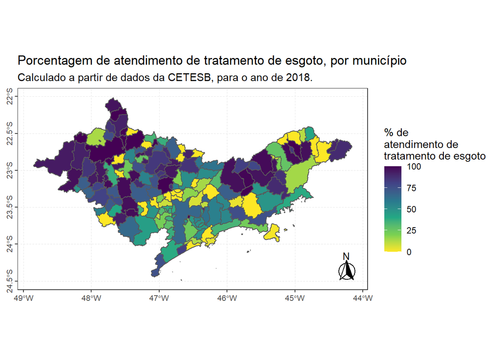

```r
saneamento %>%
  ggplot() +
  geom_sf(aes(fill = porc_real_trat)) +
  scale_fill_viridis_c(direction = -1, limits = c(0, 100)) +
  theme_bw() +
  labs(fill = "% de \natendimento de \ntratamento de esgoto ",
       title = "Porcentagem de atendimento de tratamento de esgoto, por município",
       subtitle = "Calculado a partir de dados da CETESB, para o ano de 2018.") +
  tema_mapa +
  annotation_north_arrow(
    location = "br",
    which_north = "true",
    height = unit(1, "cm"),
    width = unit(1, "cm"),
    pad_x = unit(0.1, "in"),
    pad_y = unit(0.1, "in"),
    style = north_arrow_fancy_orienteering
  )
```

Os gráficos bloxplot abaixo apresentam os valores de coleta e de tratamento de esgoto, agrupados pela UGHRI. Com o boxplot, fica mais fácil de visualizar com os dados se distribuem por UGRHI. É possível verificar que a UGRHI Litoral Norte necessita de uma melhoria no sistema de coleta (e consequentemente de tratamento) de esgotos, pois é a UGRHI com os menores percentuais de coleta de esgoto.

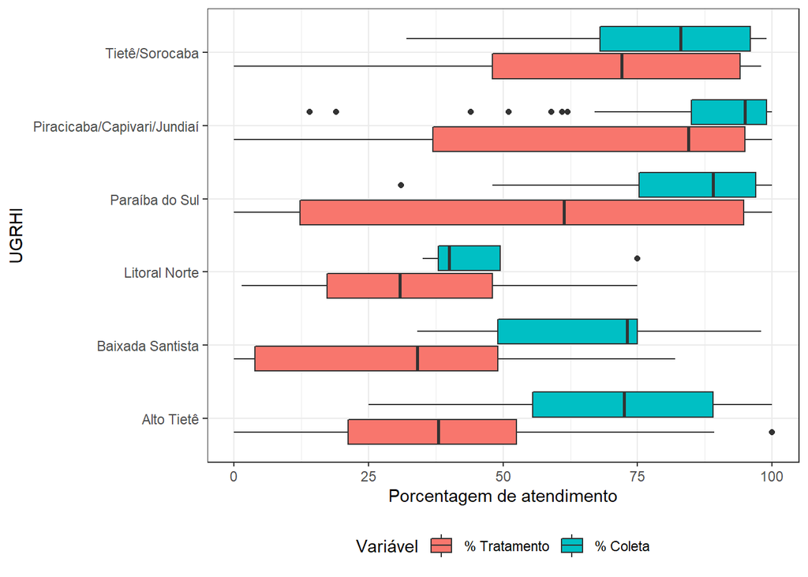

```r
saneamento %>%
  tidyr::pivot_longer(cols = c(atendimento_coleta_porc, porc_real_trat),
                      names_to = "tipo") %>%
  mutate(tipo = forcats::fct_reorder(tipo, value)) %>%
  ggplot() +
  geom_boxplot(aes(x = nome_ugrhi, y = value, fill = tipo)) +
  scale_fill_discrete(labels = c("% Tratamento", "% Coleta")) +
  coord_flip() +
  theme_bw() +
  scale_y_continuous(limits = c(0, 100)) +
  labs(x = "UGRHI",
       y = "Porcentagem de atendimento",
       fill = "Variável") +
  theme(legend.position = "bottom")
```

## Recomendações para a base da CETESB

- Adicionar uma explicação do que significa os dados de cada coluna.
- Seria melhor disponibilizar também o arquivo `.CSV`. Não disponibilizar PDFs digitalizados (como o para o ano de 2016).
- Seria útil adicionar, para os próximos relatórios, a coluna de código IBGE do município.
- Verificar a grafia do nome dos municípios (está inconsistente com a lista de municípios da Assembléia Legislativa do Estado de São Paulo[^4]): São Luiz do Paraitinga, Biritiba Mirim, Itaoca.

## Referências

ABJ. 2019. *Abjutils: Useful Tools for Jurimetrical Analysis Used by the Brazilian Jurimetrics Association*. https://github.com/abjur/abjutils.

Allaire, JJ, Yihui Xie, Jonathan McPherson, Javier Luraschi, Kevin Ushey, Aron Atkins, Hadley Wickham, Joe Cheng, Winston Chang, and Richard Iannone. 2020. *Rmarkdown: Dynamic Documents for R*. https://CRAN.R-project.org/package=rmarkdown.

Bache, Stefan Milton, and Hadley Wickham. 2014. *Magrittr: A Forward-Pipe Operator for R*. https://CRAN.R-project.org/package=magrittr.

Dunnington, Dewey. 2020. *Ggspatial: Spatial Data Framework for Ggplot2*. https://CRAN.R-project.org/package=ggspatial.

Müller, Kirill, and Hadley Wickham. 2020. *Tibble: Simple Data Frames*. https://CRAN.R-project.org/package=tibble.

Pebesma, Edzer. 2018. “Simple Features for R: Standardized Support for Spatial Vector Data.” *The R Journal* 10 (1): 439–46. https://doi.org/10.32614/RJ-2018-009.

———. 2020. *Sf: Simple Features for R*. https://CRAN.R-project.org/package=sf.

Pereira, Rafael H. M., and Caio Nogueira Goncalves. 2020. *Geobr: Loads Shapefiles of Official Spatial Data Sets of Brazil*. https://CRAN.R-project.org/package=geobr.

Persson, Eric. 2016. *Pdftables: Programmatic Conversion of Pdf Tables*. https://CRAN.R-project.org/package=pdftables.

R Core Team. 2019. *R: A Language and Environment for Statistical Computing*. Vienna, Austria: R Foundation for Statistical Computing. https://www.R-project.org/.

Wickham, Hadley. 2016. *Ggplot2: Elegant Graphics for Data Analysis*. Springer-Verlag New York. https://ggplot2.tidyverse.org.

———. 2019. *Stringr: Simple, Consistent Wrappers for Common String Operations*. https://CRAN.R-project.org/package=stringr.

Wickham, Hadley, Winston Chang, Lionel Henry, Thomas Lin Pedersen, Kohske Takahashi, Claus Wilke, Kara Woo, Hiroaki Yutani, and Dewey Dunnington. 2020. *Ggplot2: Create Elegant Data Visualisations Using the Grammar of Graphics*. https://CRAN.R-project.org/package=ggplot2.

Wickham, Hadley, Romain François, Lionel Henry, and Kirill Müller. 2020. *Dplyr: A Grammar of Data Manipulation*. https://CRAN.R-project.org/package=dplyr.

Wickham, Hadley, Jim Hester, and Romain Francois. 2018. *Readr: Read Rectangular Text Data*. https://CRAN.R-project.org/package=readr.

Xie, Yihui. 2015. *Dynamic Documents with R and Knitr*. 2nd ed. Boca Raton, Florida: Chapman; Hall/CRC. https://yihui.org/knitr/.

———. 2020. *Knitr: A General-Purpose Package for Dynamic Report Generation in R*. https://CRAN.R-project.org/package=knitr.

Xie, Yihui, J. J. Allaire, and Garrett Grolemund. 2018. *R Markdown: The Definitive Guide*. Boca Raton, Florida: Chapman; Hall/CRC. https://bookdown.org/yihui/rmarkdown.

[^1]: Plano Diretor de Aproveitamento dos Recursos Hídricos para a Macrometrópole Paulista - http://www.daee.sp.gov.br/
[^2]: https://cetesb.sp.gov.br/
[^3]: https://www.al.sp.gov.br/documentacao/municipios-paulistas/
[^4]: https://www.al.sp.gov.br/documentacao/municipios-paulistas/